# Inequality in Incarceration: Statistics

Michelle Arquiza

2022-11-22

## Abstract

Within the past few decades, the population of people in jail has shot up–but not necessarily in a proportionate fashion. Due to the stark inequality of incarceration statistics among different racial groups, the main question of this report is how this inequality has developed and whether this inequality has grown or reduced (or fluctuated). To address this, I will analyze the different incarceration trends among different racial groups throughout the years; along with other facets of their intersectional identity such as gender, age, and location.

## Introduction

American prison systems have been widely known to disproportionately incarcerate people of color. This obvious problem stems from systems of power, both socially and politically, that uphold racism and stereotypes throughout society in incarceration systems and in “normal” everyday social interactions—which causes these to feed and propagate upon one another. Adult people of color are directly affected by becoming victims of over-policing and blatant racism, while younger children of color are affected in two ways. One is directly through racism that’s supported by these displays; think, for example, discriminatory school policies, overpolicing of children of color, or ordinary interactions with bigoted people. Another is indirectly through the general attitude of society towards them. For example, this could mean always feeling lesser than and being seen as more “criminal”, which leads to misconceptions about the trajectory of their futures. As such, the research into this data set seeks to answer the questions: who are the people most affected by this overpolicing, and how has this changed over the years? Is American society developing to be less discriminatory, or does there seem to be no change?

## Data Summary

I wanted to see how the most current jail statistics were affected by disproportionate policing, so I decided to compare different racial groups’ percentages of incarcerated population. I filtered to obtain the most relevant year as well as grouped all the values together; in doing so, I wanted to see recent evidence of inequality nationwide. In analyzing the data, the group with the highest amount of incarcerated population is the Black population, with a percentage of 0.91%, which may look unassuming however when put into relation against thousands to millions of US citizens is a fair amount. The highest amount of incarcerated Black population is DC. Follows are the remaining percentages: the Native American population at 0.6%, Latinx population at 0.3%, White population at 0.28%, and Asian American & Pacific Islander population at 0.05%. As shown, there is a large gap between the incarcerated Black population as compared to the rest, so through this data analysis we have A) ensured that there *is* a quantifiable inequality within the prison system and B) understood that this overpolicing and disproportionate incarceration heavily affects the Black population, most especially in the nation’s capital.

## Growth of the U.S. Prison Population

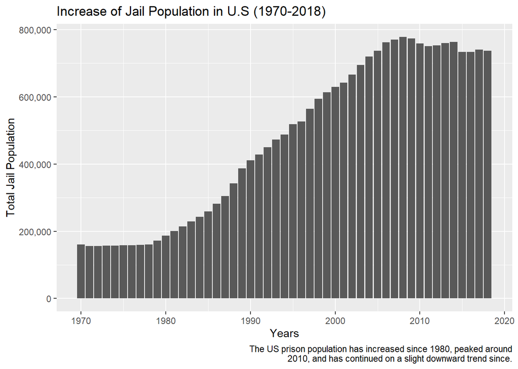

## Growth of Prison Population by State

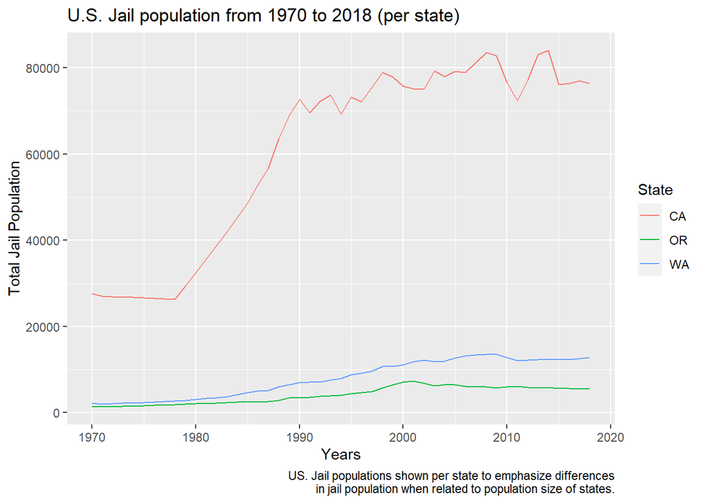

While the previous chart shows national prison population from 1970-2018, this chart shows prison population per state–specifically, the states of Washington, Oregon, and California. It’s easy to see that while all of the populations trend up, Californias prison population is far higher than Washington and Oregon. This is evident of the way prison populations rise faster with a higher overall population; since California has a higher overall population compared to the other two states recorded in this chart. These three states were chosen to represent how higher population sizes correlate to higher prison population sizes, since (in order) California has a higher population count, followed by Washington then Oregon. This chart speaks to the question of the relationship between population size and prison population, but then again brings up a question: are individual states the problem when looking at prison population trends? For example, California with a far higher prison population may have worse discrimination within their incarceration systems–would Californian systems be the problem, or the federal/national system as a whole?

[figure not shown]

This chart compares female and male incarceration rates to answer the question: is one gender disproportionately jailed? It appears that the male incarcerated population is far higher compared to the female incarcerated population on average throughout different jails in the United States as of recently. By looking at the trnd line, we can see that there are about 6 men for every 1 woman in prison. This shows that men are far more likely to be put in jail than women are. This is an upward trend that had only one outlier (a single prison with over 15k men compared to a few thousand woman) which was filtered out. This brings up the question: what facet of the incarceration system causes this?

## Percentage of Incarcerated Black Population Compared to Total Population

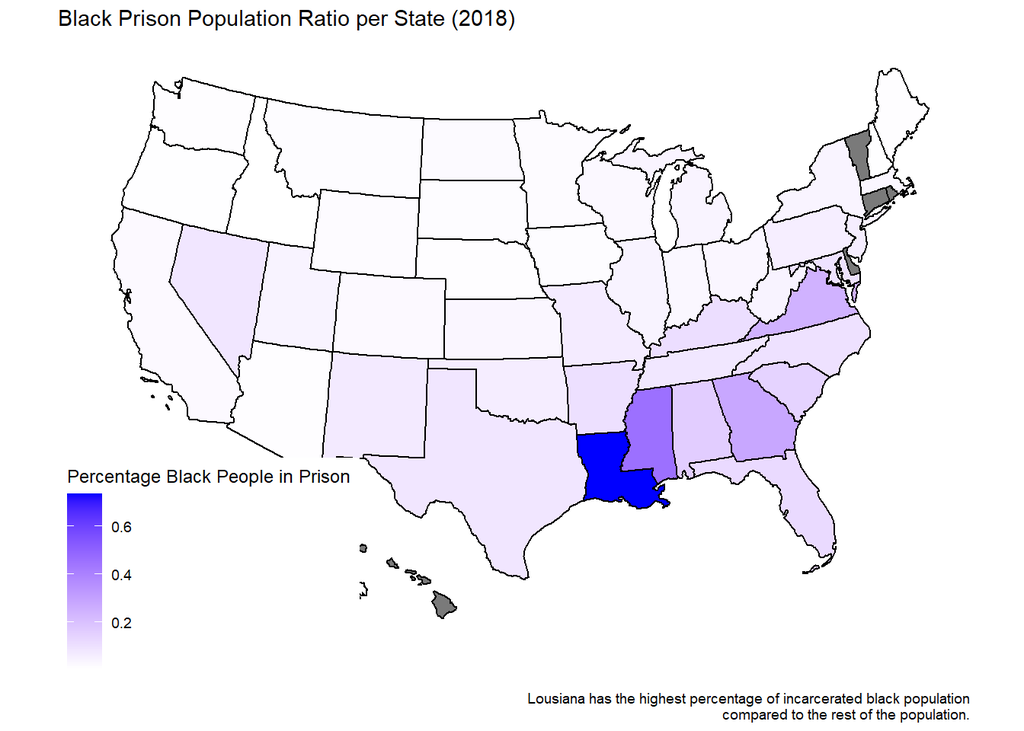

This map shows the percentage of the total population of the state that is incarcerated Black people. This answers the question of which area has the most incarcerated black population–not only does Louisiana have the highest percentage, the surrounding states also seem to have a relatively high ratio as well. This shows that the region with the highest incarcerated black people per total population is the Southeastern U.S., while the region with the least apprears to be the Northwest. This brings up the final question: why is this the Southeast of the US have such a high incarcerated Black population, while th Northwest doesn’t? What is the difference between these two regions (population and policy wise)?